# II - Libraries for science: Numpy, Matplotlib, Scipy

## II-1 Libraries

- Python allow the development and the use of third-party libraries.
- These libraries (often called modules) are a set of python elements (functions, classes, *etc*) that can be used in any program.
- We'll see here 3 libraries dédicated to data analysis, simulation or plotting.
  - Numpy : basic scientific computation
  - Matplotlib: for figures
  - Scipy: for data fitting

## II-2 Numpy

- Numpy is a free and open source library.
- Its documentation can be found [here](https://numpy.org/devdocs/).
- It provides a set of functions to mainly create and manipulate a new types of object:
  - *numpy.ndarray* : n-dimensions arrays
- Libraries are imported with the intruction: `import`
- And usually with an alias, with the keyword `as`

```python
import numpy

# or better

import numpy as np
```

- Then, one can call its elements such as the function:

```python
print(np.sqrt(9))
```

```
3.0
```

### II-2-a Mathematical functions

- Numpy defines a large number of standard mathematical functions:
  - Trigonometric functions: **cos**, **sin** **tan**, **arccos**, **arcsin**, **arctan**, **cosh**, **sinh**, **tanh**
  - Log nd exp functions: **log**, **log10**, **exp**, *etc*.
  - Power and root functions : **sqrt**, **cbrt**, **pow**, **square**
  - Rounding and absolute value : **abs**, **round**, **floor**, **ceil**.
  - And [Many others](https://numpy.org/doc/stable/reference/routines.math.html).

```python
a = -2
print(np.abs(a))
print(np.exp(a))
```

```
2
0.1353352832366127
```

- It also defines some usefull constants.
  - $\pi$ : `pi`
  - Exponentiel number $e$ : `e`
  - Infinity: `infty` ou `inf`
  - The *not a number* : `nan`

```python
print(np.pi)
print(np.cos(np.pi))
```

```
3.141592653589793
-1.0
```

```python
print(np.e)
print(np.log(np.e))
print(np.e**(-2), np.exp(-2))
```

```
2.718281828459045
1.0
0.1353352832366127 0.1353352832366127
```

```python
print(np.infty)
print(np.infty + 1)
```

```
inf
inf
```

```python
print(np.nan)
print(np.nan + 1)
```

```
nan
nan
```

### II-2-b Numpy arrays

- The main interest of the Numpy library is its new kind af object, expecially suited for scientific computation is the n-dimentionnal array: `numpy.ndarray` (just called array)
- It is usually created from a list (but not necessary).
- Be carefull: it looks like a list but it's very different and way much more efficient.

```python
lis = [1.2, 5.9, 12.0]
tab = np.array(lis)
print(lis, type(lis))
print(tab, type(tab))
```

```
[1.2, 5.9, 12.0] <class 'list'>
[ 1.2  5.9 12. ] <class 'numpy.ndarray'>
```

```python
print(type(tab))
print(tab.dtype)
```

```
<class 'numpy.ndarray'>
float64
```

- Indexing is done in the same way as for list yet also acceptin tuple, for multidimensions indexing.

```python
print(tab)
print(tab[0])
print(tab[2])
```

```
[ 1.2  5.9 12. ]
1.2
12.0
```

- The main interest of Numpy arrays compared to list, is the possibility to perform vector operation rather than just scalar ones (with basic Python operations).
- Operators are directly aplied to the whoe array and the resulting values are stored in a new array.

```python
tab_2 = tab * 2
tab_3 = tab + 5
print(tab)
print(tab_2)
print(tab_3)
```

```
[ 1.2  5.9 12. ]
[ 2.4 11.8 24. ]
[ 6.2 10.9 17. ]
```

- Mathematical operations can be directly performed between array, elementwise.

```python
tab_4 = tab_2 + tab_3
print(tab_2)
print(tab_3)
print(tab_4)
```

```
[ 2.4 11.8 24. ]
[ 6.2 10.9 17. ]
[ 8.6 22.7 41. ]
```

- Even better math function of the numpy library can be applied on arrays (in addition to scalars) !

```python
print(tab)
print(np.sqrt(9))
print(np.sqrt(tab))
```

```
[ 1.2  5.9 12. ]
3.0
[1.09544512 2.42899156 3.46410162]
```

- Which also work with your owned defined functions (if they rely on numpy math functions).

```python
def ma_fonction(x):
    return 3*x + 2

print(ma_fonction(tab))
```

```
[ 5.6 19.7 38. ]
```

### II-2-c Array creation

```python
t1 = np.zeros(5)
print(t1)
```

```
[0. 0. 0. 0. 0.]
```

```python
t2 = np.ones(5)
print(t2)
```

```
[1. 1. 1. 1. 1.]
```

```python
t3 = np.arange(0, 3, 0.5)
print(t3)
```

```
[0.  0.5 1.  1.5 2.  2.5]
```

```python
t4 = np.linspace(0, 3, 7)
print(t4)
```

```
[0.  0.5 1.  1.5 2.  2.5 3. ]
```

- One can also create N-dimension arrays, which are convenient for data storing.

```python
length_dim = (2, 5) # rows, colunms

tab_2d_0 = np.zeros(length_dim)
print(tab_2d_0)

tab_2d_1 = np.ones(length_dim)
print(tab_2d_1)
```

```
[[0. 0. 0. 0. 0.]
 [0. 0. 0. 0. 0.]]
[[1. 1. 1. 1. 1.]
 [1. 1. 1. 1. 1.]]
```

```python
tab_1d = np.arange(25)
print(tab_1d)

length_dim = (5, 5)  # rows, colunms
tab_2d = np.reshape(tab_1d, length_dim)
print(tab_2d)
```

```
[ 0  1  2  3  4  5  6  7  8  9 10 11 12 13 14 15 16 17 18 19 20 21 22 23
 24]
[[ 0  1  2  3  4]
 [ 5  6  7  8  9]
 [10 11 12 13 14]
 [15 16 17 18 19]
 [20 21 22 23 24]]
```

### II-2-d Array Indexing

- Array indexing is basically done in the same way as standard list but with more options:
  - a tuple of indices can be used to index multi-dimension array.
  - more features to come later.

```python
print(tab_2d)
print(tab_2d[1, 2]) # value at row 1 and column 2
print(tab_2d[1, :]) # all tha values of row 1
print(tab_2d[:, 3]) # all the values of column 3
print(tab_2d[0:2, 0:2]) # the top left 2x2 array
```

```
[[ 0  1  2  3  4]
 [ 5  6  7  8  9]
 [10 11 12 13 14]
 [15 16 17 18 19]
 [20 21 22 23 24]]
7
[5 6 7 8 9]
[ 3  8 13 18 23]
[[0 1]
 [5 6]]
```

### II-2-e Arrays manipulation

- There are many convenient function for array manipulation:
- Thty can be applied on separated dimensions of the array
  - flip along one several dimensions: `flip`
  - shift along one several dimensions: `roll`
  - calculate the sum or the product along one several dimensions: `sum` et `prod`
  - calculate the mean or the std along one several dimensions: `mean` et `std`
  - copy an array (true copy not reference): `copy`

```python
print(tab_2d)
```

```
[[ 0  1  2  3  4]
 [ 5  6  7  8  9]
 [10 11 12 13 14]
 [15 16 17 18 19]
 [20 21 22 23 24]]
```

```python
print(np.flip(tab_2d)) # flip both dimensions
```

```
[[24 23 22 21 20]
 [19 18 17 16 15]
 [14 13 12 11 10]
 [ 9  8  7  6  5]
 [ 4  3  2  1  0]]
```

```python
np.flip(tab_2d, axis=0) # flip along the rows
```

```
array([[20, 21, 22, 23, 24],
       [15, 16, 17, 18, 19],
       [10, 11, 12, 13, 14],
       [ 5,  6,  7,  8,  9],
       [ 0,  1,  2,  3,  4]])
```

```python
np.flip(tab_2d, axis=1) # flip along the columns
```

```
array([[ 4,  3,  2,  1,  0],
       [ 9,  8,  7,  6,  5],
       [14, 13, 12, 11, 10],
       [19, 18, 17, 16, 15],
       [24, 23, 22, 21, 20]])
```

```python
tab_2d = np.arange(10).reshape([5,2]) # array of 5 rows and 2 columns
print(tab_2d)
```

```
[[0 1]
 [2 3]
 [4 5]
 [6 7]
 [8 9]]
```

```python
print(np.sum(tab_2d)) # sum all the elements
```

```
45
```

```python
print(np.sum(tab_2d, axis=0)) # sum along the rows
```

```
[20 25]
```

```python
print(np.sum(tab_2d, axis=1)) # sum along the columns
```

```
[ 1  5  9 13 17]
```

- One can also easily concatenate or stack arrays

```python
t1 = np.arange(0, 5)
t2 = np.arange(5, 10)

print(t1)
print("---")
print(t2)
print("---")
print(np.concatenate([t1, t2]))
print("---")
print(np.vstack([t1, t2]))
print("---")
print(np.hstack([t1, t2]))
```

```
[0 1 2 3 4]
---
[5 6 7 8 9]
---
[0 1 2 3 4 5 6 7 8 9]
---
[[0 1 2 3 4]
 [5 6 7 8 9]]
---
[0 1 2 3 4 5 6 7 8 9]
```

```python
t1 = np.arange(0, 10).reshape([2, 5]) # 2 rows and 5 columns
t2 = np.arange(10, 20).reshape([2, 5]) # 2 rows and 5 columns

print(t1)
print("---")
print(t2)
print("---")
print(np.concatenate([t1, t2]))
print("---")
print(np.vstack([t1, t2]))
print("---")
print(np.hstack([t1, t2]))
```

```
[[0 1 2 3 4]
 [5 6 7 8 9]]
---
[[10 11 12 13 14]
 [15 16 17 18 19]]
---
[[ 0  1  2  3  4]
 [ 5  6  7  8  9]
 [10 11 12 13 14]
 [15 16 17 18 19]]
---
[[ 0  1  2  3  4]
 [ 5  6  7  8  9]
 [10 11 12 13 14]
 [15 16 17 18 19]]
---
[[ 0  1  2  3  4 10 11 12 13 14]
 [ 5  6  7  8  9 15 16 17 18 19]]
```

### II-2-f Input/output files

- Numpy provides function to save an array in a file or reading it from a file:

```python
my_array = np.zeros([2, 5])
print(my_array)
```

```
[[0. 0. 0. 0. 0.]
 [0. 0. 0. 0. 0.]]
```

- In text format (convenient for small 1D or 2D arrays): `savetxt` and `loadtxt`

```python
np.savetxt("file_name.txt", my_array) # Save
my_array = np.loadtxt("file_name.txt") # Load
```

- In a dedicated binary format (much more efficient, especially for Gate trees): `save` and `load` (extension `.npy`)

```python
np.save("file_name.npy", my_array) # Save
my_array = np.load("file_name.npy") # Load
```

- One can also save several several arrays in a single file (in binary): `savez` (extension `.npz`)

```python
np.savez("file_name.npz", my_array_name_1=my_array, my_array_name_2=my_array) # Save
my_arrays = np.load("file_name.npz") # Load the whole file
print(my_arrays.files)
my_array_1 = my_arrays["my_array_name_1"] # get array 1
my_array_2 = my_arrays["my_array_name_2"] # get array 2
print(my_array_1)
print(my_array_2)
```

```
['my_array_name_1', 'my_array_name_2']
[[0. 0. 0. 0. 0.]
 [0. 0. 0. 0. 0.]]
[[0. 0. 0. 0. 0.]
 [0. 0. 0. 0. 0.]]
```

### II-2-g Structured Arrays

- Numpy provides a more advanced version of its standard array called the structured array (or record array).
- Their main features compared to stndard arrays are:
  - Data are more easily accessed by columns
  - Columns have a name
  - Each column can be of a different type (an even a array)
- They are the most convenient (numpy) object for data analysis.
- This is the one to be used for Gate as they are the closest object to a root tree.

```python
s_tab = np.zeros(5, dtype=[("colonne_1", int), ("colonne_2", float), ("colonne_3", bool)])
print(s_tab) # their printing is quite ugly
```

```
[(0, 0., False) (0, 0., False) (0, 0., False) (0, 0., False)
 (0, 0., False)]
```

- Lines are accessed by standard indexing.

```python
print(s_tab[0])
```

```
(0, 0., False)
```

- Columns are accessed by its name.

```python
print(s_tab["colonne_1"])
print(s_tab["colonne_3"])
```

```
[0 0 0 0 0]
[False False False False False]
```

## II-3 Matplotlib

- **Matplotlib** (and in particular its sub-module **matplotlib.pyplot**) is the graphical library that allow to produce nice figures of all kinds.
- As for each library, it comes with its own [online documentation](https://matplotlib.org/).
- It's a quite rich library providing tones of graphical options.

```python
import matplotlib.pyplot as plt
```

### II-3-a Images

- Image (black and white) are basically 2D-arrays with the values corresponding to a value on a colorscale.
- The `imshow` function can be used to display these 2D-arrays.

```python
imag = np.loadtxt('image.txt')
print(imag)
```

```
[[0. 0. 1. ... 2. 2. 2.]
 [0. 0. 1. ... 2. 2. 2.]
 [1. 1. 1. ... 2. 2. 2.]
 ...
 [1. 1. 1. ... 1. 1. 1.]
 [0. 0. 0. ... 1. 1. 1.]
 [0. 0. 0. ... 1. 1. 1.]]
```

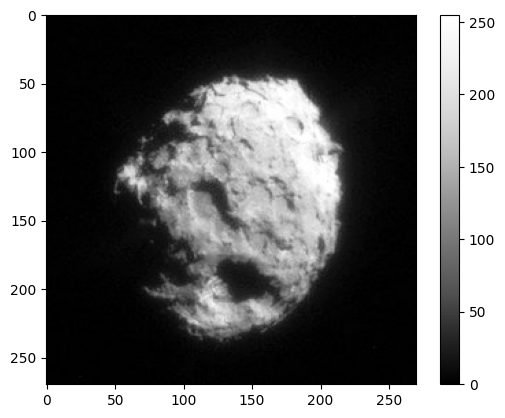

```python
plt.figure() # create a new figure
plt.imshow(imag, cmap='Greys_r') # draw the image
plt.colorbar() # draw the colorscale
plt.show() # display the image
```

- Various colormap can be used.
- The colormap list can be found [here](https://matplotlib.org/tutorials/colors/colormaps.html?highlight=colormap)

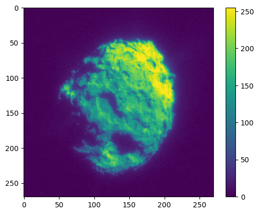

```python
plt.figure()
plt.imshow(imag, cmap='viridis') #the (current) default colormap
plt.colorbar()
plt.show()
```

### II-3-b XY plots

- The probably most common figure one have to create are the basic cartesian *xy plots*.
- This is easily dome by using the `plot` function with the following arguments:
  - an array (or list) `x` pour the abscissae
  - an array (or list) `y` pour the ordinates
- This is very useful to plot mathematical functions.

```python
def square(x):
    return x**2
```

```python
x = np.arange(-5, 5, 0.1) # from -5 (included) to 5 (excluded) by step of 0.1
y = square(x)
```

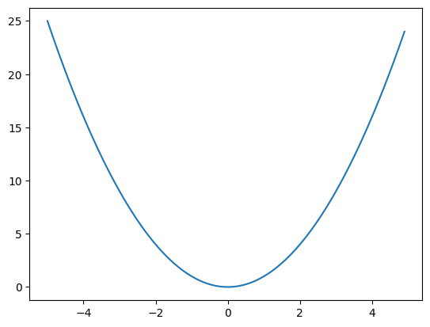

```python
plt.figure() # create the figure
plt.plot(x, y) # draw the curve
plt.show() # display the figure
```

- By default a solid line is drawn between the points.
- Discret markers can also be drawn instead or in addition.
- They are selected by passing a character:
  - `"o"` for a large dot;
  - `"x"` for a cross ;
  - `"-"` for a solid line ;
  - "`--"` for a dashed line ;
  - *etc*.
  - The **markers** list can be found [here](https://matplotlib.org/api/markers_api.html?highlight=marker#module-matplotlib.markers).
- The color of the marker/line can be changed by passing a character as an argument.
- The color list can be found [here](https://matplotlib.org/stable/tutorials/colors/colors.html).

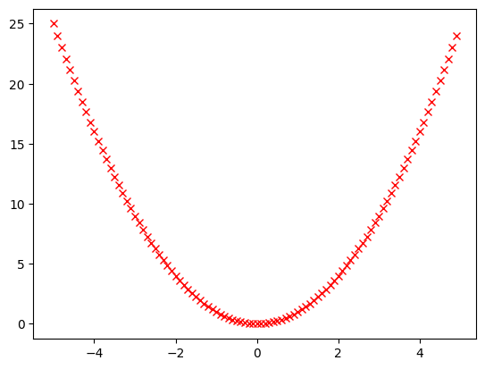

```python
plt.figure()
plt.plot(x, y, 'rx') # red cross
plt.show()
```